# Progress Memo 1

Final Project  
Data Science 1 with R (STAT 301-1)

Author

Jessie Chen

Published

October 29, 2023

**Github Repo Link**

To link to your github **repo**sitory, appropriately edit the example link below. Meaning replace `https://your-github-repo-url` with your github repo url. Suggest verifying the link works before submitting.

[My Repo Link](https://github.com/stat301-1-2023-fall/final-project-1-Jchench)

```r
# Loading packages:
library(tidyverse)
library(naniar)
```

## Data source

```r
# Loading data:

spotify_data_top <-
  read_csv("data/ATop 1990-2022.csv")

spotify_streams <-
  read_csv("data/spotify_streams.csv")
```

The `spotify_data_top` dataset I am using collected Spotify-made playlists that include between 50-130 tracks of the most popular songs each year from 1990-2022. There is information on each song’s artist, album release date, genre, and other characteristics (i.e. BPM, key, and time signature). [This data was taken from Kaggle, courtesy of user KRISTOFFER.](https://www.kaggle.com/datasets/ztofff/top-1990-2022)

I anticipate joining these data sets together and one way I could match them would be through the song name and artist name variables, which are listed differently in each dataset. Thus, I would have to rename these columns later so that they are consistent.

## Why this data

I chose to use these datasets because I think it would be interesting to look at the songs that were considered “popular” throughout the years form 1990-2022. The `spotify_data_top` has a lot of comprehensive information on the musical elements of each individual song (e.g. dancebility, genres, time signature, and key), and I think it could be useful to analyze if there are any correlations among these elements and “popularity”. The `spotify_streams` dataset provides a more concrete, quantitative measure of “popularity” through collecting the number of streams (or how many times the song is played on the platform) for each song. Thus, I think it would be helpful to merge these two datasets together to look at the number of streams as an indicator of popularity.

## Data quality & complexity check

**Looking briefly at the data:**

```r
glimpse(spotify_data_top)
```

```
Rows: 2,610
Columns: 26
$ `#`                 <dbl> 1, 2, 3, 4, 5, 6, 7, 8, 9, 10, 11, 12, 13, 14, 15,…
$ Song                <chr> "As It Was", "Heat Waves", "STAY (with Justin Bieb…
$ Artist              <chr> "Harry Styles", "Glass Animals", "The Kid LAROI,Ju…
$ Popularity          <dbl> 91, 91, 86, 91, 88, 86, 82, 91, 89, 86, 82, 83, 88…
$ BPM                 <dbl> 174, 81, 170, 92, 107, 116, 77, 128, 80, 108, 150,…
$ Genres              <chr> "pop", "gauze pop, indietronica, modern rock, pov:…
$ `Parent Genres`     <chr> "Pop", "Pop, Rock", "Hip Hop, Pop", "Latin", "Lati…
$ Album               <chr> "As It Was", "Dreamland", "STAY (with Justin Biebe…
$ `Album Date`        <chr> "2022-03-31", "2020-08-07", "2021-07-09", "2022-05…
$ Time                <time> 02:47:00, 03:58:00, 02:21:00, 02:58:00, 04:03:00,…
$ Dance               <dbl> 52, 76, 59, 91, 65, 80, 73, 62, 65, 63, 74, 70, 80…
$ Energy              <dbl> 73, 53, 76, 71, 72, 80, 78, 78, 69, 55, 70, 54, 48…
$ Acoustic            <dbl> 34, 44, 4, 9, 10, 3, 24, 1, 8, 72, 2, 30, 14, 19, …
$ Instrumental        <dbl> 0, 0, 0, 0, 0, 0, 0, 3, 0, 0, 0, 0, 0, 0, 0, 0, 0,…
$ Happy               <dbl> 66, 53, 48, 43, 19, 94, 56, 55, 27, 19, 89, 42, 23…
$ Speech              <dbl> 0, 0, 0, 0, 20, 0, 20, 0, 0, 0, 0, 0, 0, 0, 0, 0, …
$ Live                <dbl> 30, 0, 10, 0, 10, 10, 40, 20, 50, 0, 0, 30, 0, 40,…
$ Loud                <dbl> -5, -7, -5, -5, -5, -6, -4, -6, -6, -13, -7, -6, -…
$ Key                 <chr> "F#/G♭ Minor", "B Major", "C♯/D♭ Major", "C♯/D♭ Mi…
$ `Time Signature`    <dbl> 4, 4, 4, 4, 4, 4, 4, 4, 4, 4, 4, 4, 4, 4, 3, 4, 4,…
$ `Added At`          <date> 2023-08-14, 2023-08-14, 2023-08-14, 2023-08-14, 2…
$ `Spotify Track Id`  <chr> "4LRPiXqCikLlN15c3yImP7", "3USxtqRwSYz57Ewm6wWRMp"…
$ `Album Label`       <chr> "Columbia", "Polydor Records", "Columbia", "Rimas …
$ Camelot             <chr> "11A", "1B", "3B", "12A", "4A", "3B", "10A", "10B"…
$ `Spotify Track Img` <chr> "https://p.scdn.co/mp3-preview/c43dd07043b29e800c1…
$ `Song Preview`      <chr> "https://i.scdn.co/image/ab67616d00004851b46f74097…
```

```r
glimpse(spotify_streams)
```

```
Rows: 11,084
Columns: 9
$ Position                 <dbl> 1, 2, 3, 4, 5, 6, 7, 8, 9, 10, 11, 12, 13, 14…
$ `Artist Name`            <chr> "Post Malone", "Juice WRLD", "Lil Uzi Vert", …
$ `Song Name`              <chr> "Sunflower  SpiderMan: Into the SpiderVerse",…
$ Days                     <dbl> 1506, 1673, 1853, 2547, 1223, 1995, 1100, 167…
$ `Top 10 (xTimes)`        <dbl> 302, 178, 212, 6, 186, 4, 233, 44, 133, 2, 15…
$ `Peak Position`          <dbl> 1, 1, 1, 7, 1, 8, 1, 2, 1, 5, 1, 1, 1, 1, 5, …
$ `Peak Position (xTimes)` <chr> "(x29)", "(x20)", "(x4)", "0", "(x124)", "0",…
$ `Peak Streams`           <dbl> 2118242, 2127668, 1660502, 659366, 2905678, 9…
$ `Total Streams`          <dbl> 883369738, 864832399, 781153024, 734857487, 7…
```

The datasets seem to be sufficiently complex. `spotify_data_top` has 2610 observations and 26 variables. There are 12 categorical, 12 numeric, and 2 date and time-related variables. `spotify_streams` has 11084 rows and 9 variables. There are 3 categorical and 6 numeric variables.

**Checking for missingness in `spotify_data_top`:**

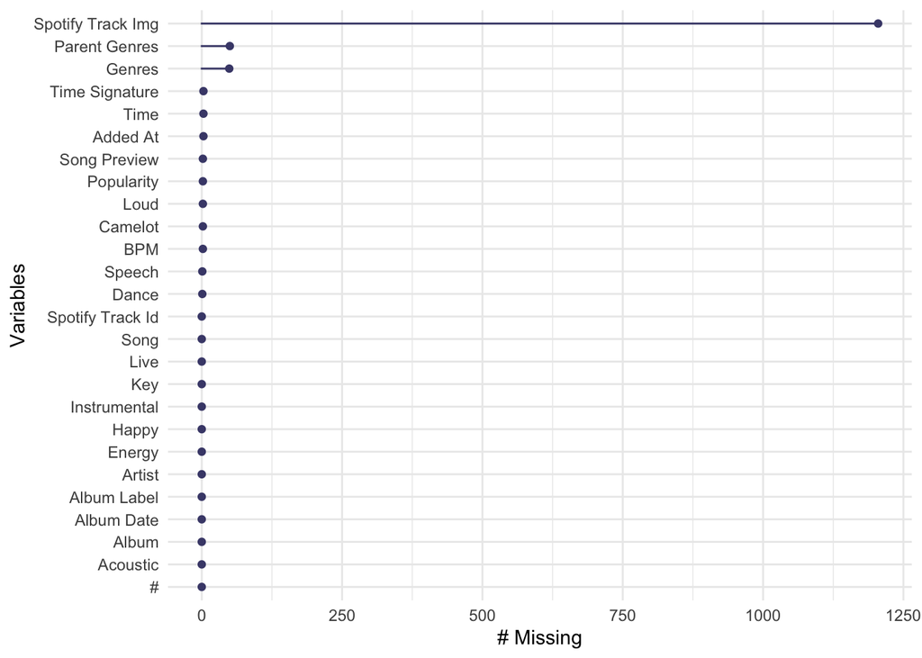

```r
gg_miss_var(spotify_data_top)
```

```r
miss_var_summary(spotify_data_top) |>
  filter(n_miss != 0)
```

```
# A tibble: 13 × 3
   variable          n_miss pct_miss
   <chr>              <int>    <dbl>
 1 Spotify Track Img   1205  46.2
 2 Parent Genres         50   1.92
 3 Genres                49   1.88
 4 Time                   3   0.115
 5 Time Signature         3   0.115
 6 Added At               3   0.115
 7 Popularity             2   0.0766
 8 BPM                    2   0.0766
 9 Loud                   2   0.0766
10 Camelot                2   0.0766
11 Song Preview           2   0.0766
12 Dance                  1   0.0383
13 Speech                 1   0.0383
```

**Checking for missingness in `spotify_streams`:**

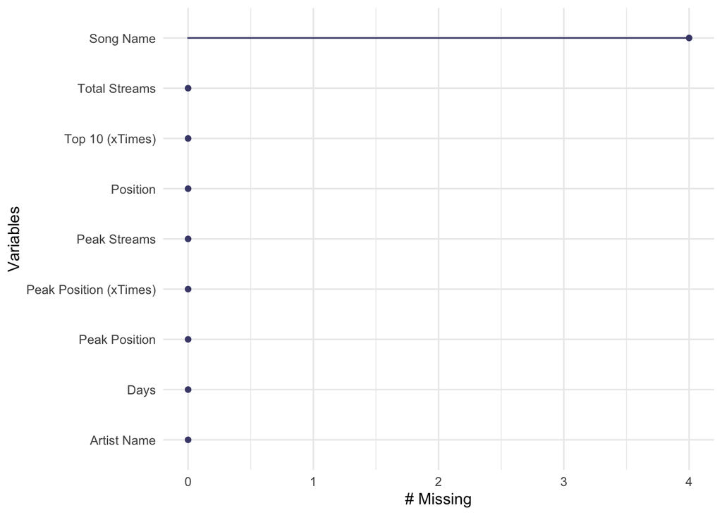

```r
gg_miss_var(spotify_streams)
```

```r
miss_var_summary(spotify_streams) |>
  filter(n_miss != 0)
```

```
# A tibble: 1 × 3
  variable  n_miss pct_miss
  <chr>      <int>    <dbl>
1 Song Name      4   0.0361
```

This dataset only has one variable with missing values and it is `Song Name`. Unfortunately, this will make things a little bit more difficult going forwards because it won’t be as easy to merge by song and artist name.

## Potential data issues

One potential issue I’m going to face in terms of merging is having to remove/ work around missing values. Since I’m thinking of merging by song and artist name, it will be a bit hard since a couple of song names in the `spotify_streams` dataset is missing. Another challenge I will face will be regarding the `date` and `time` variables in the `spotify_data_top` dataset. I might have to mutate the `date` column so that it shows the year, month, day separately. I may also need to find a better way to represent `time` numerically (perhaps convert to seconds). I also need to rename/ infer descriptions for a lot of the columns because the variable names are not quite clear in displaying what they’re representing. For example, the `time` variable actually represents the length of the song in minutes and seconds. Another issue is that the `spotify_data_top` dataset does not have any information on songs from 2021, [^1] which will impact my analysis going forward if I decide to look at songs across time. Overall, the datasets seem relatively clean.

## Misc

**Potential timeline:** I’m hoping to have my data fully cleaned and organized by the end of next week so I can start doing some initial exploration.

## Footnotes

[^1]: the Kaggle user who provided this dataset could not find any information from 2021